# Análisis_de_ventas (1)

### Importación de datos

```python
import pandas as pd
import matplotlib.pyplot as plt
from matplotlib.patches import FancyBboxPatch
import plotly.graph_objects as go
import seaborn as sns
import plotly.express as px

url = "https://raw.githubusercontent.com/alura-es-cursos/challenge1-data-science-latam/refs/heads/main/base-de-datos-challenge1-latam/tienda_1%20.csv"
url2 = "https://raw.githubusercontent.com/alura-es-cursos/challenge1-data-science-latam/refs/heads/main/base-de-datos-challenge1-latam/tienda_2.csv"
url3 = "https://raw.githubusercontent.com/alura-es-cursos/challenge1-data-science-latam/refs/heads/main/base-de-datos-challenge1-latam/tienda_3.csv"
url4 = "https://raw.githubusercontent.com/alura-es-cursos/challenge1-data-science-latam/refs/heads/main/base-de-datos-challenge1-latam/tienda_4.csv"

tienda = pd.read_csv(url)
tienda2 = pd.read_csv(url2)
tienda3 = pd.read_csv(url3)
tienda4 = pd.read_csv(url4)

tienda.head()
```

|  | Producto | Categoría del Producto | Precio | Costo de envío | Fecha de Compra | Vendedor | Lugar de Compra | Calificación | Método de pago | Cantidad de cuotas | lat | lon |
| --- | --- | --- | --- | --- | --- | --- | --- | --- | --- | --- | --- | --- |
| 0 | Asistente virtual | Electrónicos | 164300.0 | 6900.0 | 16/01/2021 | Pedro Gomez | Bogotá | 4 | Tarjeta de crédito | 8 | 4.60971 | -74.08175 |
| 1 | Mesa de comedor | Muebles | 192300.0 | 8400.0 | 18/05/2022 | Beatriz Morales | Medellín | 1 | Tarjeta de crédito | 4 | 6.25184 | -75.56359 |
| 2 | Juego de mesa | Juguetes | 209600.0 | 15900.0 | 15/03/2021 | Juan Fernandez | Cartagena | 1 | Tarjeta de crédito | 1 | 10.39972 | -75.51444 |
| 3 | Microondas | Electrodomésticos | 757500.0 | 41000.0 | 03/05/2022 | Juan Fernandez | Cali | 4 | Nequi | 1 | 3.43722 | -76.52250 |
| 4 | Silla de oficina | Muebles | 335200.0 | 20200.0 | 07/11/2020 | Maria Alfonso | Medellín | 5 | Nequi | 1 | 6.25184 | -75.56359 |

```python
tienda2.head()
```

|  | Producto | Categoría del Producto | Precio | Costo de envío | Fecha de Compra | Vendedor | Lugar de Compra | Calificación | Método de pago | Cantidad de cuotas | lat | lon |
| --- | --- | --- | --- | --- | --- | --- | --- | --- | --- | --- | --- | --- |
| 0 | Silla de oficina | Muebles | 283600.0 | 15300.0 | 04/08/2021 | Izabela de León | Medellín | 1 | Nequi | 1 | 6.25184 | -75.56359 |
| 1 | Pandereta | Instrumentos musicales | 76800.0 | 2300.0 | 26/11/2020 | Blanca Ramirez | Medellín | 3 | Tarjeta de crédito | 4 | 6.25184 | -75.56359 |
| 2 | Cama king | Muebles | 443300.0 | 23800.0 | 22/10/2021 | Izabela de León | Pereira | 5 | Tarjeta de crédito | 10 | 4.81333 | -75.69611 |
| 3 | Cama king | Muebles | 906200.0 | 46400.0 | 04/05/2022 | Maria Alfonso | Cali | 5 | Tarjeta de crédito | 10 | 3.43722 | -76.52250 |
| 4 | Silla de oficina | Muebles | 397800.0 | 19400.0 | 26/02/2022 | Lucas Olivera | Bogotá | 4 | Tarjeta de crédito | 3 | 4.60971 | -74.08175 |

```python
tienda3.head()
```

|  | Producto | Categoría del Producto | Precio | Costo de envío | Fecha de Compra | Vendedor | Lugar de Compra | Calificación | Método de pago | Cantidad de cuotas | lat | lon |
| --- | --- | --- | --- | --- | --- | --- | --- | --- | --- | --- | --- | --- |
| 0 | Secadora de ropa | Electrodomésticos | 1285100.0 | 66600.0 | 17/12/2021 | Camila Rivera | Santa Marta | 4 | Tarjeta de crédito | 4 | 11.24079 | -74.19904 |
| 1 | Mesa de noche | Muebles | 290100.0 | 13600.0 | 10/02/2021 | Maria Alfonso | Cali | 3 | Tarjeta de crédito | 1 | 3.43722 | -76.52250 |
| 2 | Guitarra acústica | Instrumentos musicales | 303500.0 | 17400.0 | 22/01/2023 | Lucas Olivera | Bogotá | 5 | Tarjeta de crédito | 3 | 4.60971 | -74.08175 |
| 3 | Balón de voleibol | Deportes y diversión | 58800.0 | 3300.0 | 22/03/2022 | Pedro Gomez | Barranquilla | 4 | Tarjeta de crédito | 6 | 10.96854 | -74.78132 |
| 4 | Armario | Muebles | 521100.0 | 25900.0 | 12/01/2022 | Blanca Ramirez | Bogotá | 1 | Tarjeta de crédito | 1 | 4.60971 | -74.08175 |

```python
tienda4.head()
```

|  | Producto | Categoría del Producto | Precio | Costo de envío | Fecha de Compra | Vendedor | Lugar de Compra | Calificación | Método de pago | Cantidad de cuotas | lat | lon |
| --- | --- | --- | --- | --- | --- | --- | --- | --- | --- | --- | --- | --- |
| 0 | Lavavajillas | Electrodomésticos | 1084800.0 | 56000.0 | 11/11/2022 | Rafael Acosta | Bogotá | 4 | Tarjeta de crédito | 3 | 4.60971 | -74.08175 |
| 1 | Cama box | Muebles | 473800.0 | 25400.0 | 03/01/2020 | Izabela de León | Cúcuta | 5 | Tarjeta de crédito | 2 | 7.89391 | -72.50782 |
| 2 | Balón de baloncesto | Deportes y diversión | 23700.0 | 0.0 | 25/12/2022 | Maria Alfonso | Medellín | 5 | Nequi | 1 | 6.25184 | -75.56359 |
| 3 | Modelado predictivo | Libros | 57700.0 | 1300.0 | 23/11/2021 | Lucas Olivera | Medellín | 3 | Nequi | 1 | 6.25184 | -75.56359 |
| 4 | Auriculares | Electrónicos | 138900.0 | 5600.0 | 25/04/2022 | Blanca Ramirez | Bogotá | 4 | Tarjeta de crédito | 7 | 4.60971 | -74.08175 |

# 1. Análisis de facturación

Calcular el ingreso total de cada tienda. Sumando los valores de la columna Precio de cada conjunto de datos de la tienda para estimar los ingresos.

Tienda 1

```python
facturacion_tienda = tienda['Precio'].sum()
print("La facturacion total de la primera tienda es:", facturacion_tienda)
```

```
La facturacion total de la primera tienda es: 1150880400.0
```

Tienda 2

```python
facturacion_tienda2 = tienda2['Precio'].sum()
print("La facturacion total de la primera tienda es:", facturacion_tienda2)
```

```
La facturacion total de la primera tienda es: 1116343500.0
```

Tienda 3

```python
facturacion_tienda3 = tienda3['Precio'].sum()
print("La facturacion total de la primera tienda es:", facturacion_tienda3)
```

```
La facturacion total de la primera tienda es: 1098019600.0
```

Tienda 4

```python
facturacion_tienda4 = tienda4['Precio'].sum()
print("La facturacion total de la primera tienda es:", facturacion_tienda4)
```

```
La facturacion total de la primera tienda es: 1038375700.0
```

Resumen de facturacion por tienda

```
Tabla resumen de facturación por tienda:
```

|  | Tienda | Facturación |
| --- | --- | --- |
| 0 | Tienda 1 | 1,150,880,400 |
| 1 | Tienda 2 | 1,116,343,500 |
| 2 | Tienda 3 | 1,098,019,600 |
| 3 | Tienda 4 | 1,038,375,700 |
| 4 | Total General | 4,403,619,200 |

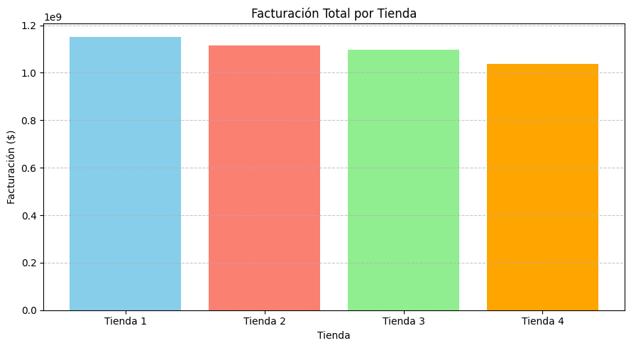

```python
# Se crea diccionario y DataFrame con las 4 tiendas
datos = {
    'Tienda': ['Tienda 1', 'Tienda 2', 'Tienda 3', 'Tienda 4'],
    'Facturación': [facturacion_tienda, facturacion_tienda2, facturacion_tienda3, facturacion_tienda4]
}
df_resumen = pd.DataFrame(datos)

# Se calcula el total general
total_general = df_resumen['Facturación'].sum()

# Se agrega fila de total al DataFrame
df_resumen.loc[len(df_resumen)] = ['Total General', total_general]

# Formatear facturación con separador de miles
df_resumen['Facturación'] = df_resumen['Facturación'].map('{:,.0f}'.format)

# Mostrar tabla resumen
print("Tabla resumen de facturación por tienda:")
display(df_resumen)

# --- Gráfico de barras (sin el total general) ---
plt.figure(figsize=(9, 5))
plt.bar(['Tienda 1', 'Tienda 2', 'Tienda 3', 'Tienda 4'],
        [facturacion_tienda, facturacion_tienda2, facturacion_tienda3, facturacion_tienda4],
        color=['skyblue', 'salmon', 'lightgreen', 'orange'])

plt.title('Facturación Total por Tienda')
plt.xlabel('Tienda')
plt.ylabel('Facturación ($)')
plt.grid(axis='y', linestyle='--', alpha=0.7)
plt.tight_layout()
plt.show()
```

# 2. Ventas por categoría

```python
# Agrupar y contar por Categoría para cada tienda, agregando total al final

# Tienda 1
categorias_tienda = tienda['Categoría del Producto'].value_counts().reset_index()
categorias_tienda.columns = ['Categoría', 'Cantidad']

# Agregar fila de total
total1 = pd.DataFrame([{'Categoría': 'TOTAL', 'Cantidad': categorias_tienda['Cantidad'].sum()}])
categorias_tienda1 = pd.concat([categorias_tienda, total1], ignore_index=True)

# Tienda 2
categorias_tienda2 = tienda2['Categoría del Producto'].value_counts().reset_index()
categorias_tienda2.columns = ['Categoría', 'Cantidad']

total2 = pd.DataFrame([{'Categoría': 'TOTAL', 'Cantidad': categorias_tienda2['Cantidad'].sum()}])
categorias_tienda2 = pd.concat([categorias_tienda2, total2], ignore_index=True)

# Tienda 3
categorias_tienda3 = tienda3['Categoría del Producto'].value_counts().reset_index()
categorias_tienda3.columns = ['Categoría', 'Cantidad']

total3 = pd.DataFrame([{'Categoría': 'TOTAL', 'Cantidad': categorias_tienda3['Cantidad'].sum()}])
categorias_tienda3 = pd.concat([categorias_tienda3, total3], ignore_index=True)

# Tienda 4
categorias_tienda4 = tienda4['Categoría del Producto'].value_counts().reset_index()
categorias_tienda4.columns = ['Categoría', 'Cantidad']

total4 = pd.DataFrame([{'Categoría': 'TOTAL', 'Cantidad': categorias_tienda4['Cantidad'].sum(),}])
categorias_tienda4 = pd.concat([categorias_tienda4, total4], ignore_index=True)

# Mostrar resultados
print("📌 Cantidad de productos vendidos por categoría - Tienda 1")
display(categorias_tienda1)

print("📌 Cantidad de productos vendidos por categoría - Tienda 2")
display(categorias_tienda2)

print("📌 Cantidad de productos vendidos por categoría - Tienda 3")
display(categorias_tienda3)

print("📌 Cantidad de productos vendidos por categoría - Tienda 4")
display(categorias_tienda4)
```

```
📌 Cantidad de productos vendidos por categoría - Tienda 1
```

|  | Categoría | Cantidad |
| --- | --- | --- |
| 0 | Muebles | 465 |
| 1 | Electrónicos | 448 |
| 2 | Juguetes | 324 |
| 3 | Electrodomésticos | 312 |
| 4 | Deportes y diversión | 284 |
| 5 | Instrumentos musicales | 182 |
| 6 | Libros | 173 |
| 7 | Artículos para el hogar | 171 |
| 8 | TOTAL | 2359 |

```
📌 Cantidad de productos vendidos por categoría - Tienda 2
```

|  | Categoría | Cantidad |
| --- | --- | --- |
| 0 | Muebles | 442 |
| 1 | Electrónicos | 422 |
| 2 | Juguetes | 313 |
| 3 | Electrodomésticos | 305 |
| 4 | Deportes y diversión | 275 |
| 5 | Instrumentos musicales | 224 |
| 6 | Libros | 197 |
| 7 | Artículos para el hogar | 181 |
| 8 | TOTAL | 2359 |

```
📌 Cantidad de productos vendidos por categoría - Tienda 3
```

|  | Categoría | Cantidad |
| --- | --- | --- |
| 0 | Muebles | 499 |
| 1 | Electrónicos | 451 |
| 2 | Juguetes | 315 |
| 3 | Electrodomésticos | 278 |
| 4 | Deportes y diversión | 277 |
| 5 | Libros | 185 |
| 6 | Instrumentos musicales | 177 |
| 7 | Artículos para el hogar | 177 |
| 8 | TOTAL | 2359 |

```
📌 Cantidad de productos vendidos por categoría - Tienda 4
```

|  | Categoría | Cantidad |
| --- | --- | --- |
| 0 | Muebles | 480 |
| 1 | Electrónicos | 451 |
| 2 | Juguetes | 338 |
| 3 | Deportes y diversión | 277 |
| 4 | Electrodomésticos | 254 |
| 5 | Artículos para el hogar | 201 |
| 6 | Libros | 187 |
| 7 | Instrumentos musicales | 170 |
| 8 | TOTAL | 2358 |

# 3. Calificación promedio de la tienda

```python
# Calcular calificación promedio por tienda
promedio_calificacion1 = tienda['Calificación'].mean()
promedio_calificacion2 = tienda2['Calificación'].mean()
promedio_calificacion3 = tienda3['Calificación'].mean()
promedio_calificacion4 = tienda4['Calificación'].mean()

# Crear un DataFrame con los resultados
calificaciones_promedio = pd.DataFrame({
    'Tienda': ['Tienda 1', 'Tienda 2', 'Tienda 3', 'Tienda 4'],
    'Calificación Promedio': [
        round(promedio_calificacion1, 2),
        round(promedio_calificacion2, 2),
        round(promedio_calificacion3, 2),
        round(promedio_calificacion4, 2)
    ]
})

# Mostrar el resultado
print("⭐ Calificación promedio por tienda:")
display(calificaciones_promedio)
```

```
⭐ Calificación promedio por tienda:
```

|  | Tienda | Calificación Promedio |
| --- | --- | --- |
| 0 | Tienda 1 | 3.98 |
| 1 | Tienda 2 | 4.04 |
| 2 | Tienda 3 | 4.05 |
| 3 | Tienda 4 | 4.00 |

```python
# Crear un gauge para cada tienda
fig = go.Figure()

for i, row in calificaciones_promedio.iterrows():
    fig.add_trace(go.Indicator(
        mode="gauge+number",
        value=row['Calificación Promedio'],
        title={'text': row['Tienda']},
        gauge={'axis': {'range': [0, 5]}},
        domain={'row': i // 2, 'column': i % 2}
    ))

fig.update_layout(
    grid={'rows': 2, 'columns': 2, 'pattern': "independent"},
    title="⭐ Calificación Promedio por Tienda"
)
fig.show()
```

[interactive chart not shown]

# 4. Productos más y menos vendidos

```python
def analizar_top_bottom_tienda(df, nombre_tienda):
    # Contar productos vendidos
    ventas = df['Producto'].value_counts().reset_index()
    ventas.columns = ['Producto', 'Cantidad Vendida']

    top5 = ventas.head(5)
    bottom5 = ventas.tail(5)

    print(f"\n📍 {nombre_tienda}")
    print("🔝 Top 5 más vendidos:")
    print(top5.to_string(index=False))

    print("\n🔻 Bottom 5 menos vendidos:")
    print(bottom5.to_string(index=False))

    # Visualización conjunta en subplots
    fig, axes = plt.subplots(1, 2, figsize=(14, 5))

    sns.barplot(data=top5, x='Cantidad Vendida', y='Producto', ax=axes[0], palette='crest')
    axes[0].set_title('Top 5 más vendidos')

    sns.barplot(data=bottom5, x='Cantidad Vendida', y='Producto', ax=axes[1], palette='rocket')
    axes[1].set_title('Bottom 5 menos vendidos')

    for ax in axes:
        ax.set_xlabel('Cantidad Vendida')
        ax.set_ylabel('Producto')

    fig.suptitle(f'Análisis de ventas en {nombre_tienda}', fontsize=14)
    plt.tight_layout(rect=[0, 0, 1, 0.95])
    plt.show()
```

```
📍 Tienda 1
🔝 Top 5 más vendidos:
        Producto  Cantidad Vendida
      Microondas                60
   TV LED UHD 4K                60
         Armario                60
Secadora de ropa                58
   Mesa de noche                56

🔻 Bottom 5 menos vendidos:
                   Producto  Cantidad Vendida
Ciencia de datos con Python                39
                  Pandereta                36
            Olla de presión                35
  Auriculares con micrófono                33
               Celular ABXY                33
```

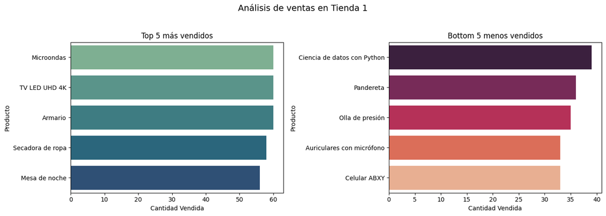

```
📍 Tienda 2
🔝 Top 5 más vendidos:
                 Producto  Cantidad Vendida
Iniciando en programación                65
               Microondas                62
                  Batería                61
        Guitarra acústica                58
                Pandereta                58

🔻 Bottom 5 menos vendidos:
       Producto  Cantidad Vendida
    Auriculares                37
         Sillón                35
Mesa de comedor                34
      Impresora                34
  Juego de mesa                32
```

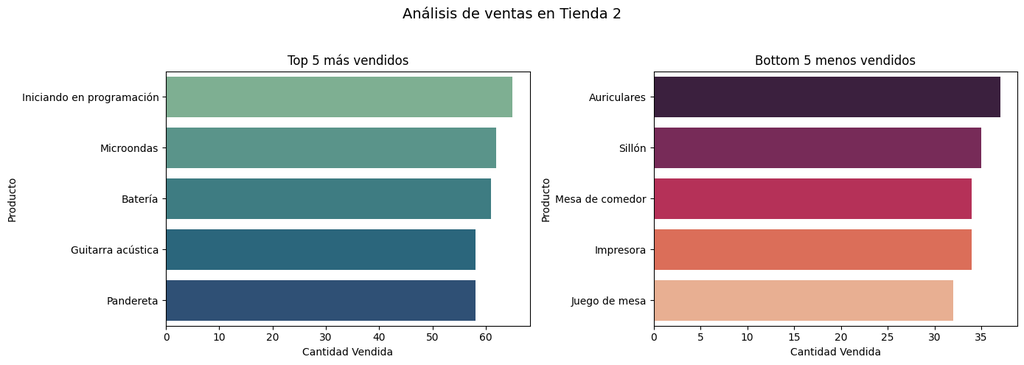

```
📍 Tienda 3
🔝 Top 5 más vendidos:
       Producto  Cantidad Vendida
  Kit de bancas                57
Mesa de comedor                56
      Cama king                56
   Set de ollas                55
  Mesa de noche                55

🔻 Bottom 5 menos vendidos:
               Producto  Cantidad Vendida
     Guitarra eléctrica                38
           Set de vasos                36
                Mochila                36
             Microondas                36
Bloques de construcción                35
```

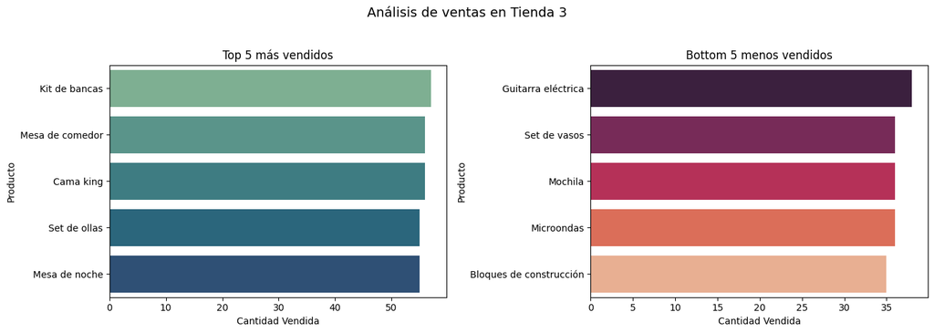

```
📍 Tienda 4
🔝 Top 5 más vendidos:
                 Producto  Cantidad Vendida
                 Cama box                62
               Cubertería                59
  Dashboards con Power BI                56
                Cama king                56
Carrito de control remoto                55

🔻 Bottom 5 menos vendidos:
                   Producto  Cantidad Vendida
               Refrigerador                38
Ciencia de datos con Python                38
          Guitarra acústica                37
                    Armario                34
         Guitarra eléctrica                33
```

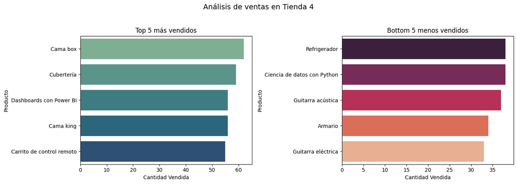

```python
# Supongamos que tenés 4 DataFrames: tienda1, tienda2, tienda3, tienda4

analizar_top_bottom_tienda(tienda, "Tienda 1")
analizar_top_bottom_tienda(tienda2, "Tienda 2")
analizar_top_bottom_tienda(tienda3, "Tienda 3")
analizar_top_bottom_tienda(tienda4, "Tienda 4")
```

# 5. Envío promedio por tienda

```python
# Lista con tus DataFrames
tiendas = [tienda, tienda2, tienda3, tienda4]
nombres_tiendas = ['Tienda 1', 'Tienda 2', 'Tienda 3', 'Tienda 4']

# Lista para guardar resultados
costos_promedio_envio = []

# Calcular el costo promedio de envío por tienda
for df, nombre in zip(tiendas, nombres_tiendas):
    if 'Costo de envío' in df.columns:
        promedio_envio = df['Costo de envío'].mean()
        costos_promedio_envio.append({'Tienda': nombre, 'Costo Promedio de Envío': promedio_envio})
    else:
        print(f"⚠️ La columna 'Costo de envío' no existe en {nombre}")

# Convertir a DataFrame
df_envios_promedio = pd.DataFrame(costos_promedio_envio)
print(df_envios_promedio)
```

```
     Tienda  Costo Promedio de Envío
0  Tienda 1             26018.609580
1  Tienda 2             25216.235693
2  Tienda 3             24805.680373
3  Tienda 4             23459.457167
```

```python
fig = px.bar(df_envios_promedio,
             x='Tienda',
             y='Costo Promedio de Envío',
             text='Costo Promedio de Envío',
             title='📦 Costo Promedio de Envío por Tienda',
             color='Tienda',
             color_discrete_sequence=px.colors.qualitative.Vivid)

fig.update_traces(texttemplate='%{text:.2s}', textposition='outside')
fig.update_layout(uniformtext_minsize=8, uniformtext_mode='hide')
fig.show()
```

[interactive chart not shown]

# 🏪 Informe de Evaluación de Tiendas para Decisión Estratégica

## 📌 Introducción

Este informe tiene como propósito analizar el desempeño de cuatro tiendas pertenecientes a la misma cadena comercial. El objetivo principal es **identificar cuál de las tiendas presenta un rendimiento comparativamente más bajo** y, por tanto, podría ser considerada para su venta, liberando así recursos que permitan al propietario invertir en un nuevo emprendimiento.

El análisis se realiza teniendo en cuenta los siguientes indicadores clave:

- Facturación total.
- Calificación promedio otorgada por los clientes.
- Costo promedio de envío.
- Rendimiento del producto más vendido.
- Similitud en el portafolio de productos por categoría.

Los datos fueron obtenidos de los registros históricos de ventas, calificaciones y costos logísticos de cada tienda. Se emplearon visualizaciones interactivas y estadísticas descriptivas para respaldar las conclusiones.

## 📊 Desarrollo del Análisis

### 1. 💰 Facturación por Tienda

| Tienda | Facturación |
| --- | --- |
| Tienda 1 | 1.150.880.400 |
| Tienda 2 | 1.116.343.500 |
| Tienda 3 | 1.098.019.600 |
| **Tienda 4** | **1.038.375.700** |
| **Total General** | **4.403.619.200** |

📉 **Observación:** La Tienda 4 es la que **menos factura**, con una diferencia cercana a **60 millones respecto a Tienda 3**, y **más de 110 millones menos** que Tienda 1.

### 2. ⭐ Calificación Promedio de Clientes

| Tienda | Calificación Promedio |
| --- | --- |
| Tienda 1 | 3.98 |
| Tienda 2 | 4.04 |
| **Tienda 3** | **4.05** |
| Tienda 4 | 4.00 |

📉 **Observación:** Aunque la diferencia es leve, **Tienda 3 presenta la mejor valoración de clientes**. Tienda 4 no destaca significativamente en este aspecto.

### 3. 🚚 Costo Promedio de Envío

| Tienda | Costo Promedio de Envío |
| --- | --- |
| Tienda 1 | 26,018 |
| Tienda 2 | 25,216 |
| Tienda 3 | 24,805 |
| **Tienda 4** | **23,459** |

✅ **Observación:** Tienda 4 es la más eficiente en términos de logística, con el costo de envío promedio más bajo. No obstante, esta **fortaleza no se traduce en una ventaja competitiva significativa en facturación ni satisfacción del cliente**.

### 4. 📦 Producto más Vendido

| Tienda | Ventas del producto más vendido |
| --- | --- |
| Tienda 1 | 60 |
| **Tienda 2** | **65** |
| Tienda 3 | 57 |
| Tienda 4 | 62 |

📈 **Observación:** Tienda 4 tiene un buen desempeño en su producto estrella, aunque no lidera en esta métrica.

### 5. 📦 Distribución por Categoría

Se constató que **todas las tiendas manejan una proporción similar de productos por categoría**, lo que permite una comparación justa y objetiva de su rendimiento global.

## 📌 Conclusión y Recomendación

Luego del análisis de los datos disponibles, se concluye que:

🔴 **Tienda 4 presenta el rendimiento global más bajo**, siendo la tienda con:

- La **menor facturación total**, lo que indica un menor retorno financiero.
- Una **calificación promedio apenas superior a la más baja**, sin destacar frente a las otras tiendas.
- Aunque tiene el **costo logístico más bajo**, **esto no se refleja en una mayor satisfacción ni rentabilidad**.

✅ Si bien **la eficiencia logística de Tienda 4 es una fortaleza**, no es suficiente para compensar su bajo rendimiento financiero ni su impacto en la percepción del cliente.

### ✅ Recomendación:

> 💡 **Se recomienda vender Tienda 4 y destinar esos recursos a un nuevo emprendimiento**, ya que representa la **unidad con menor rendimiento general** en la cadena y su cierre tendría **el menor impacto negativo sobre las operaciones globales**.

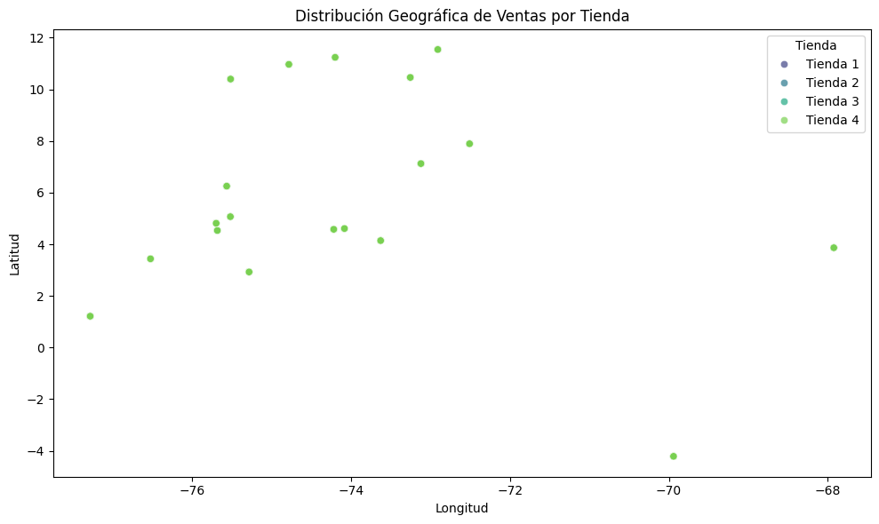

```python
import folium
from folium.plugins import HeatMap
from google.colab import files

# Lista de DataFrames (ya definidos anteriormente)
# tiendas = [tienda1, tienda2, tienda3, tienda4]
# nombres_tiendas = ['Tienda 1', 'Tienda 2', 'Tienda 3', 'Tienda 4']

# Agregamos la columna de tienda a cada dataframe
for i in range(len(tiendas)):
    tiendas[i]['Tienda'] = nombres_tiendas[i]

# Concatenamos todas las tiendas en un único DataFrame
df_total = pd.concat(tiendas, ignore_index=True)

# ============ Gráfico de dispersión geográfico ==============
plt.figure(figsize=(10, 6))
sns.scatterplot(data=df_total, x='lon', y='lat', hue='Tienda', palette='viridis', alpha=0.7)
plt.title('Distribución Geográfica de Ventas por Tienda')
plt.xlabel('Longitud')
plt.ylabel('Latitud')
plt.legend(title="Tienda")
plt.tight_layout()

# Guardamos la imagen en el entorno de Colab
plt.savefig("distribucion_geografica.png")
plt.show()

# Descargamos la imagen si se desea
files.download("distribucion_geografica.png")
```

```python
# Creamos el mapa centrado en Colombia (aproximadamente)
mapa = folium.Map(location=[4.5709, -74.2973], zoom_start=6)

# Extraemos las coordenadas (latitud, longitud)
coordenadas = df_total[['lat', 'lon']].dropna().values.tolist()

# Agregamos el HeatMap al mapa
HeatMap(coordenadas, radius=10, blur=15).add_to(mapa)

# Mostramos el mapa interactivo
mapa
```

Make this Notebook Trusted to load map: File -> Trust Notebook

[interactive chart not shown]

## Análisis Geográfico de Ventas por Tienda

En este análisis se utilizó la información de coordenadas (latitud y longitud) para representar espacialmente las ventas de cada tienda. Se busca entender si existen patrones geográficos que influyen en el desempeño.